# DMIT Vignette: OCCAM Data-Prep with R/Looking at Census-Income Data

Dale Frakes

March 20, 2018

## Introduction

The goal of this vignette is to demonstrate taking a data set and preparing it for use with OCCAM using R. It demonstrates loading data, then using a variety of tools in R for working with categorical data (such as adjusting the levels, and binning continuous variables) then uses a function that will render an OCCAM data input file from a dataframe of factors (categorical variables).

### Datasets

We’ll be selecting a data set from the [UCIML Repository](https://archive.ics.uci.edu/ml/datasets.html). Specifically we’ll be using the Adult. It’s a collection of some census data that’s been used in many publications to show the capability of various algorithms to be able to predict if the income of a case will be above $50,000. It’s appealing for this project because it has several categorical variables and a few continuous ones.

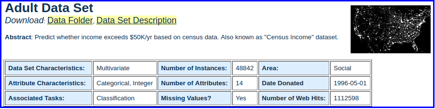

## Preparing the Data

The first step, of course, is loading the data into R so we can analyze it. The data from UCIML usually comes without headings/variable-names and has a separate file containing those. The following loads the data into a data frame called `ad` and names the columns appropriately.

```r
# read the main datafile, keeping default of strings as factors, remove any whitespace around strings
ad <- read.csv("./data/adult.data.txt", header=FALSE, strip.white = TRUE)

# read in the file with column names
an <- read.csv("./data/adult.names.txt", header=FALSE, sep=";", stringsAsFactors=FALSE)

# hard-coding that we are only interested in the rows 97-107 (the rest is just explanation)
col_names <- sapply(strsplit(as.vector(an[94:107,]),":"), "[", 1)

# remove hyphens from column names
col_names <- gsub("-", "", col_names)

col_names <- c(col_names, "income")

colnames(ad) <- col_names
```

Note that this bit of code is somewhat hard-coded for this data set and is not generally applicable.

And now that the data is loaded, let’s take a couple looks at it, just to see what’s in there. One of the things I really like about R is that it makes it pretty simple to inspect a dataset. The first thing I usually like to use is the `str` (structure) command. It gives some great details about a variable, or particularly a data frame, including data types and typical values.

```r
str(ad)
```

```
'data.frame':   32561 obs. of  15 variables:
 $ age          : int  39 50 38 53 28 37 49 52 31 42 ...
 $ workclass    : Factor w/ 9 levels "?","Federal-gov",..: 8 7 5 5 5 5 5 7 5 5 ...
 $ fnlwgt       : int  77516 83311 215646 234721 338409 284582 160187 209642 45781 159449 ...
 $ education    : Factor w/ 16 levels "10th","11th",..: 10 10 12 2 10 13 7 12 13 10 ...
 $ educationnum : int  13 13 9 7 13 14 5 9 14 13 ...
 $ maritalstatus: Factor w/ 7 levels "Divorced","Married-AF-spouse",..: 5 3 1 3 3 3 4 3 5 3 ...
 $ occupation   : Factor w/ 15 levels "?","Adm-clerical",..: 2 5 7 7 11 5 9 5 11 5 ...
 $ relationship : Factor w/ 6 levels "Husband","Not-in-family",..: 2 1 2 1 6 6 2 1 2 1 ...
 $ race         : Factor w/ 5 levels "Amer-Indian-Eskimo",..: 5 5 5 3 3 5 3 5 5 5 ...
 $ sex          : Factor w/ 2 levels "Female","Male": 2 2 2 2 1 1 1 2 1 2 ...
 $ capitalgain  : int  2174 0 0 0 0 0 0 0 14084 5178 ...
 $ capitalloss  : int  0 0 0 0 0 0 0 0 0 0 ...
 $ hoursperweek : int  40 13 40 40 40 40 16 45 50 40 ...
 $ nativecountry: Factor w/ 42 levels "?","Cambodia",..: 40 40 40 40 6 40 24 40 40 40 ...
 $ income       : Factor w/ 2 levels "<=50K",">50K": 1 1 1 1 1 1 1 2 2 2 ...
```

At this point it might also be helpful to look at the variable descriptions from the `names` file:

```r
cat(an[94:107,], sep ="\n")
```

```
age: continuous.
workclass: Private, Self-emp-not-inc, Self-emp-inc, Federal-gov, Local-gov, State-gov, Without-pay, Never-worked.
fnlwgt: continuous.
education: Bachelors, Some-college, 11th, HS-grad, Prof-school, Assoc-acdm, Assoc-voc, 9th, 7th-8th, 12th, Masters, 1st-4th, 10th, Doctorate, 5th-6th, Preschool.
education-num: continuous.
marital-status: Married-civ-spouse, Divorced, Never-married, Separated, Widowed, Married-spouse-absent, Married-AF-spouse.
occupation: Tech-support, Craft-repair, Other-service, Sales, Exec-managerial, Prof-specialty, Handlers-cleaners, Machine-op-inspct, Adm-clerical, Farming-fishing, Transport-moving, Priv-house-serv, Protective-serv, Armed-Forces.
relationship: Wife, Own-child, Husband, Not-in-family, Other-relative, Unmarried.
race: White, Asian-Pac-Islander, Amer-Indian-Eskimo, Other, Black.
sex: Female, Male.
capital-gain: continuous.
capital-loss: continuous.
hours-per-week: continuous.
native-country: United-States, Cambodia, England, Puerto-Rico, Canada, Germany, Outlying-US(Guam-USVI-etc), India, Japan, Greece, South, China, Cuba, Iran, Honduras, Philippines, Italy, Poland, Jamaica, Vietnam, Mexico, Portugal, Ireland, France, Dominican-Republic, Laos, Ecuador, Taiwan, Haiti, Col…
```

Along with the structure of the data, it’s helpful to get a `summary` of the data values within the data.

```r
summary(ad)
```

```
      age                   workclass         fnlwgt
 Min.   :17.00   Private         :22696   Min.   :  12285
 1st Qu.:28.00   Self-emp-not-inc: 2541   1st Qu.: 117827
 Median :37.00   Local-gov       : 2093   Median : 178356
 Mean   :38.58   ?               : 1836   Mean   : 189778
 3rd Qu.:48.00   State-gov       : 1298   3rd Qu.: 237051
 Max.   :90.00   Self-emp-inc    : 1116   Max.   :1484705
                 (Other)         :  981
        education      educationnum                 maritalstatus
 HS-grad     :10501   Min.   : 1.00   Divorced             : 4443
 Some-college: 7291   1st Qu.: 9.00   Married-AF-spouse    :   23
 Bachelors   : 5355   Median :10.00   Married-civ-spouse   :14976
 Masters     : 1723   Mean   :10.08   Married-spouse-absent:  418
 Assoc-voc   : 1382   3rd Qu.:12.00   Never-married        :10683
 11th        : 1175   Max.   :16.00   Separated            : 1025
 (Other)     : 5134                   Widowed              :  993
           occupation           relationship                   race
 Prof-specialty :4140   Husband       :13193   Amer-Indian-Eskimo:  311
 Craft-repair   :4099   Not-in-family : 8305   Asian-Pac-Islander: 1039
 Exec-managerial:4066   Other-relative:  981   Black             : 3124
 Adm-clerical   :3770   Own-child     : 5068   Other             :  271
 Sales          :3650   Unmarried     : 3446   White             :27816
 Other-service  :3295   Wife          : 1568
 (Other)        :9541
     sex         capitalgain     capitalloss      hoursperweek
 Female:10771   Min.   :    0   Min.   :   0.0   Min.   : 1.00
 Male  :21790   1st Qu.:    0   1st Qu.:   0.0   1st Qu.:40.00
                Median :    0   Median :   0.0   Median :40.00
                Mean   : 1078   Mean   :  87.3   Mean   :40.44
                3rd Qu.:    0   3rd Qu.:   0.0   3rd Qu.:45.00
                Max.   :99999   Max.   :4356.0   Max.   :99.00

       nativecountry     income
 United-States:29170   <=50K:24720
 Mexico       :  643   >50K : 7841
 ?            :  583
 Philippines  :  198
 Germany      :  137
 Canada       :  121
 (Other)      : 1709
```

### Fixing “Education”

“Education” appears in two different variables, one continuous, and one categorical (factor). I’m not sure we need both, so let’s take a look at the values they take together.

```r
ed <- unique(ad[c("educationnum","education")])

ed[order(ed$educationnum),]
```

```
    educationnum    education
225            1    Preschool
161            2      1st-4th
57             3      5th-6th
16             4      7th-8th
7              5          9th
78             6         10th
4              7         11th
416            8         12th
3              9      HS-grad
11            10 Some-college
15            11    Assoc-voc
14            12   Assoc-acdm
1             13    Bachelors
6             14      Masters
53            15  Prof-school
21            16    Doctorate
```

As we can see from that, it appears `educationnum` is merely a coding of `education`. Since R already encodes `education` as a factor, we can probably remove it. But before do that, we’ll want to see how `education` has been encoded as a factor. One advantage we get from `educationnum` is that the amount of education is ordered, which may make it easier to re-bin into fewer bins/factors later in our analysis. For example, we could combine the values of `educationum` from 1-12 as a single factor, “k-12”. The default factorization of `education` as it was read from the data file may end up with a less sensible order.

We can investigate how `education` was set up as a factor this way. `str` tell us the following:

```r
str(ad$education)
```

```
 Factor w/ 16 levels "10th","11th",..: 10 10 12 2 10 13 7 12 13 10 ...
```

Which makes it look like the order isn’t sensible, but is probably alphabetical, which may not be as helpful. We can confirm using `levels`, and then asking for the levels 1-5.

```r
levels(ad$education)
```

```
 [1] "10th"         "11th"         "12th"         "1st-4th"
 [5] "5th-6th"      "7th-8th"      "9th"          "Assoc-acdm"
 [9] "Assoc-voc"    "Bachelors"    "Doctorate"    "HS-grad"
[13] "Masters"      "Preschool"    "Prof-school"  "Some-college"
```

```r
levels(ad$education)[1:5]
```

```
[1] "10th"    "11th"    "12th"    "1st-4th" "5th-6th"
```

Having confirmed that the factor coding for `education` makes less sense than `educationnum`, what we’d like to do is re-factor `education` with the order provided by `educationnum`, then delete `educationnum`. Before we do that, let’s take a look at the breakdown of `education` to make sure we end up with a correct re-coding.

```r
summary(ad$education)
```

```
        10th         11th         12th      1st-4th      5th-6th
         933         1175          433          168          333
     7th-8th          9th   Assoc-acdm    Assoc-voc    Bachelors
         646          514         1067         1382         5355
   Doctorate      HS-grad      Masters    Preschool  Prof-school
         413        10501         1723           51          576
Some-college
        7291
```

Let’s use `ed` from above to set up the new factorization or `levels` for `education`. Then use that to re-factor the `education` variable.

```r
ed <- ed[order(ed$educationnum),]
levels(factor(ed$educationnum, levels=ed$education))
```

```
 [1] "Preschool"    "1st-4th"      "5th-6th"      "7th-8th"
 [5] "9th"          "10th"         "11th"         "12th"
 [9] "HS-grad"      "Some-college" "Assoc-voc"    "Assoc-acdm"
[13] "Bachelors"    "Masters"      "Prof-school"  "Doctorate"
```

```r
ad$education <- factor(ad$education, levels = as.vector(ed$education))

summary(ad$education)
```

```
   Preschool      1st-4th      5th-6th      7th-8th          9th
          51          168          333          646          514
        10th         11th         12th      HS-grad Some-college
         933         1175          433        10501         7291
   Assoc-voc   Assoc-acdm    Bachelors      Masters  Prof-school
        1382         1067         5355         1723          576
   Doctorate
         413
```

And with that summary, we can see that we’ve recoded `education` to have the correct order, and a quick comparison of the summary numbers shows that the values match after that transformation.

We can now remove `educationnum` from the dataset. We can also get rid of the `ed` data frame since we won’t use it any more.

```r
ad <- ad[, !(colnames(ad) %in% c("educationnum"))]
rm(ed)

str(ad)
```

```
'data.frame':   32561 obs. of  14 variables:
 $ age          : int  39 50 38 53 28 37 49 52 31 42 ...
 $ workclass    : Factor w/ 9 levels "?","Federal-gov",..: 8 7 5 5 5 5 5 7 5 5 ...
 $ fnlwgt       : int  77516 83311 215646 234721 338409 284582 160187 209642 45781 159449 ...
 $ education    : Factor w/ 16 levels "Preschool","1st-4th",..: 13 13 9 7 13 14 5 9 14 13 ...
 $ maritalstatus: Factor w/ 7 levels "Divorced","Married-AF-spouse",..: 5 3 1 3 3 3 4 3 5 3 ...
 $ occupation   : Factor w/ 15 levels "?","Adm-clerical",..: 2 5 7 7 11 5 9 5 11 5 ...
 $ relationship : Factor w/ 6 levels "Husband","Not-in-family",..: 2 1 2 1 6 6 2 1 2 1 ...
 $ race         : Factor w/ 5 levels "Amer-Indian-Eskimo",..: 5 5 5 3 3 5 3 5 5 5 ...
 $ sex          : Factor w/ 2 levels "Female","Male": 2 2 2 2 1 1 1 2 1 2 ...
 $ capitalgain  : int  2174 0 0 0 0 0 0 0 14084 5178 ...
 $ capitalloss  : int  0 0 0 0 0 0 0 0 0 0 ...
 $ hoursperweek : int  40 13 40 40 40 40 16 45 50 40 ...
 $ nativecountry: Factor w/ 42 levels "?","Cambodia",..: 40 40 40 40 6 40 24 40 40 40 ...
 $ income       : Factor w/ 2 levels "<=50K",">50K": 1 1 1 1 1 1 1 2 2 2 ...
```

### Removing `fnlwgt`

`fnlwgt` is some kind of weighting in the dataset that has some detailed explanation about it, but I still can’t quite make sense of how to use it. So for purposes of this analysis, I’m removing the variable.

```r
ad <- ad[, !(colnames(ad) %in% c("fnlwgt"))]
```

### Now for the Binning

In this section we’ll deal with the variables and try to feature different ways variables can be binned in R using various libraries.

Most of the variables are already categorical because they are factors. Let’s take a look at the variables that are not factors and decide how to handle them.

```r
str(ad[,!sapply(ad, is.factor)])
```

```
'data.frame':   32561 obs. of  4 variables:
 $ age         : int  39 50 38 53 28 37 49 52 31 42 ...
 $ capitalgain : int  2174 0 0 0 0 0 0 0 14084 5178 ...
 $ capitalloss : int  0 0 0 0 0 0 0 0 0 0 ...
 $ hoursperweek: int  40 13 40 40 40 40 16 45 50 40 ...
```

```r
summary(ad[,!sapply(ad, is.factor)])
```

```
      age         capitalgain     capitalloss      hoursperweek
 Min.   :17.00   Min.   :    0   Min.   :   0.0   Min.   : 1.00
 1st Qu.:28.00   1st Qu.:    0   1st Qu.:   0.0   1st Qu.:40.00
 Median :37.00   Median :    0   Median :   0.0   Median :40.00
 Mean   :38.58   Mean   : 1078   Mean   :  87.3   Mean   :40.44
 3rd Qu.:48.00   3rd Qu.:    0   3rd Qu.:   0.0   3rd Qu.:45.00
 Max.   :90.00   Max.   :99999   Max.   :4356.0   Max.   :99.00
```

#### Age

The `summary` data above help see what values `age` takes. But it might be even more helpful to see more detail. It’s an integer from 17 to 90, but it might be helpful to see the distribution.

One way is to use the `table` command. Another is to do an actual histogram as a chart.

```r
table(ad$age)
```

```
 17  18  19  20  21  22  23  24  25  26  27  28  29  30  31  32  33  34
395 550 712 753 720 765 877 798 841 785 835 867 813 861 888 828 875 886
 35  36  37  38  39  40  41  42  43  44  45  46  47  48  49  50  51  52
876 898 858 827 816 794 808 780 770 724 734 737 708 543 577 602 595 478
 53  54  55  56  57  58  59  60  61  62  63  64  65  66  67  68  69  70
464 415 419 366 358 366 355 312 300 258 230 208 178 150 151 120 108  89
 71  72  73  74  75  76  77  78  79  80  81  82  83  84  85  86  87  88
 72  67  64  51  45  46  29  23  22  22  20  12   6  10   3   1   1   3
 90
 43
```

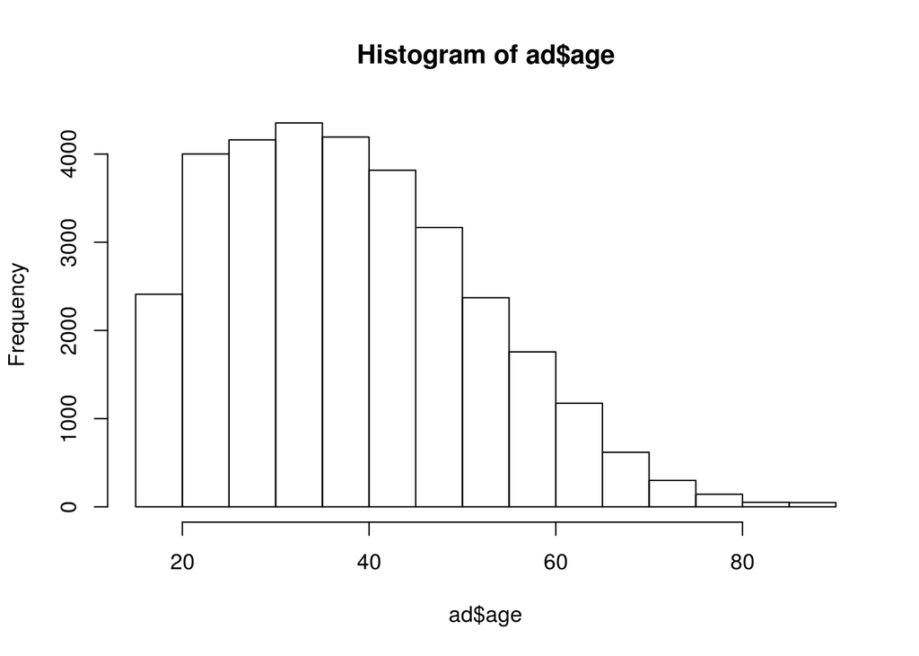

```r
hist(x = ad$age)
```

And lowest is: 15-24, 25-29, 30-34, 35-39, 40-44, 45-49, 50-54, 55-59, 60-64, 65-69, 70-74, 75+

Let’s start by using the lowest level of age hierarchy, since it’s easy to regroup them later into fewer bins.

```r
age_breaks <- seq(from = 25, to = 75, by = 5)   # all but first break are 5 years apart

age_breaks <- c(15, age_breaks)                 # insert the first value at the beginning

age_breaks <- c(age_breaks, max(ad$age))        # make sure the highest value is contained in the breaks

# confirm that our age-breaks look like what we've described above
age_breaks
```

```
 [1] 15 25 30 35 40 45 50 55 60 65 70 75 90
```

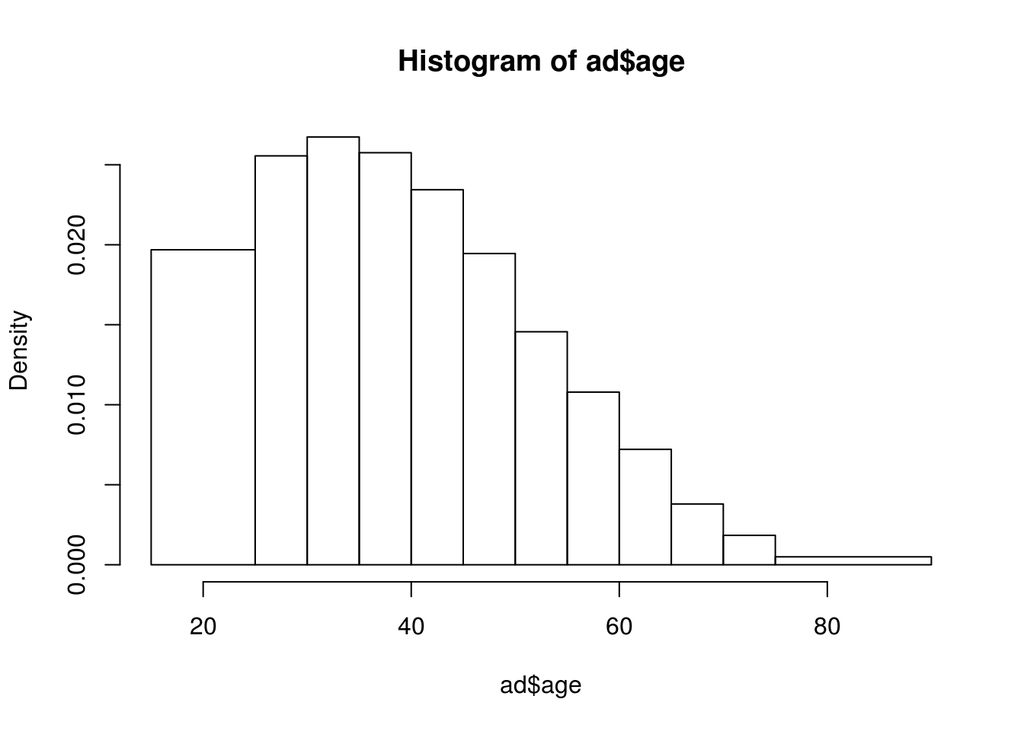

```r
# and now plot a histogram using these bins
hist(x = ad$age, breaks = age_breaks)
```

`cut` can be used with the same breaks as `hist` to bin data. `hist` can be called with a `plot = FALSE` option to then get the counts or density. A summary of `cut` with the same breaks reveals the same counts as shown in the histogram.

```r
hist(x = ad$age, breaks = age_breaks, plot = FALSE)$counts
```

```
 [1] 6411 4161 4353 4193 3816 3167 2371 1757 1174  618  299  241
```

```r
summary(cut(x=ad$age, breaks = age_breaks))
```

```
(15,25] (25,30] (30,35] (35,40] (40,45] (45,50] (50,55] (55,60] (60,65]
   6411    4161    4353    4193    3816    3167    2371    1757    1174
(65,70] (70,75] (75,90]
    618     299     241
```

And now we’re ready to replace the `age` variable with its discretized (factor) version. Note that this permanently changes the variable.

```r
ad$age <- cut(x=ad$age, breaks = age_breaks)
str(ad$age)
```

```
 Factor w/ 12 levels "(15,25]","(25,30]",..: 4 6 4 7 2 4 6 7 3 5 ...
```

```r
summary(ad$age)
```

```
(15,25] (25,30] (30,35] (35,40] (40,45] (45,50] (50,55] (55,60] (60,65]
   6411    4161    4353    4193    3816    3167    2371    1757    1174
(65,70] (70,75] (75,90]
    618     299     241
```

Before moving on, let’s look at how we would aggregate/group the levels of the age factor we just created. One easy way is to simply assign new `levels` to the variable, duplicating the new level in the position of the lower levels it encompasses. In this case, it should go from 12 levels to 7.

```r
# Old: 15-24, 25-29, 30-34, 35-39, 40-44, 45-49, 50-54, 55-59, 60-64, 65-69, 70-74, 75+
# New: 15-24, 25-34,        35-44,        45-54,        55-64,        65-74,        75+

# make a new vector with the new factor labels.  In the data above the non-end factors are grouped by 2s
# so the new vector states the new factor twice for each of those
new_age_breaks <- c("15-24",
                    "25-34", "25-34",   # encompases 25-29 and 30-34
                    "35-44", "35-44",
                    "45-54", "45-54",
                    "55-64", "55-64",
                    "65-74", "65-74",
                    "75+")

# make a copy of the age variable because we don't want to make this change to our data (just yet)
age_tmp <- ad$age

levels(age_tmp) <- new_age_breaks

str(age_tmp)
```

```
 Factor w/ 7 levels "15-24","25-34",..: 3 4 3 4 2 3 4 4 2 3 ...
```

```r
summary(age_tmp)
```

```
15-24 25-34 35-44 45-54 55-64 65-74   75+
 6411  8514  8009  5538  2931   917   241
```

A similar procedure would be followed to apply the highest level of hierarchy with just 2 levels.

Note that OCCAM offers the ability to re-bin a variable by combining existing levels (states). Also note the the above re-binning only works if new levels are a strict combination of the old levels. If you want new break-points (e.g. age 15-32), it’s necessary to apply the new bins to the original numeric data.

#### Capital-Gain

`capitalgain` is a variable that will be more challenging/interesting than `age`. It is not evenly distributed and has a lot of sparseness. This will offer an opportunity to explore other binning options in R.

```r
summary(ad$capitalgain)
```

```
   Min. 1st Qu.  Median    Mean 3rd Qu.    Max.
      0       0       0    1078       0   99999
```

```r
table(ad$capitalgain)
```

```
    0   114   401   594   914   991  1055  1086  1111  1151  1173  1409
29849     6     2    34     8     5    25     4     1     8     3     7
 1424  1455  1471  1506  1639  1797  1831  1848  2009  2036  2050  2062
    3     1     7    15     1     7     7     6     3     4     5     2
 2105  2174  2176  2202  2228  2290  2329  2346  2354  2387  2407  2414
    9    48    23    16     5     5     6     6    11     1    19     8
 2463  2538  2580  2597  2635  2653  2829  2885  2907  2936  2961  2964
   11     1    12    20    11     5    31    24    11     3     3     9
 2977  2993  3103  3137  3273  3325  3411  3418  3432  3456  3464  3471
    8     2    97    37     6    53    24     5     4     2    23     8
 3674  3781  3818  3887  3908  3942  4064  4101  4386  4416  4508  4650
   14    12     7     6    32    14    42    20    70    12    12    41
 4687  4787  4865  4931  4934  5013  5060  5178  5455  5556  5721  6097
    3    23    17     1     7    69     1    97    11     5     3     1
 6360  6418  6497  6514  6723  6767  6849  7298  7430  7443  7688  7896
    3     9    11     5     2     5    27   246     9     5   284     3
 7978  8614  9386  9562 10520 10566 10605 11678 13550 14084 14344 15020
    1    55    22     4    43     6    12     2    27    41    26     5
15024 15831 18481 20051 22040 25124 25236 27828 34095 41310 99999
  347     6     2    37     1     4    11    34     5     2   159
```

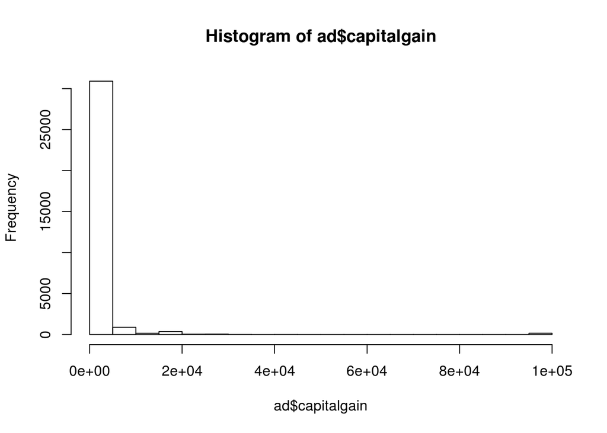

```r
hist(ad$capitalgain)
```

As we can see, a vast majority of cases have 0 capital gains, so maybe it was interesting to exclude that value and see what’s in there.

```r
summary(ad$capitalgain[ad$capitalgain>0])
```

```
   Min. 1st Qu.  Median    Mean 3rd Qu.    Max.
    114    3411    7298   12939   14084   99999
```

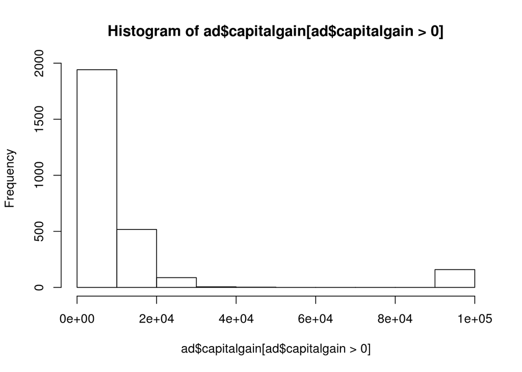

```r
hist(ad$capitalgain[ad$capitalgain>0])
```

Considering capital-gains are something most people don’t have, maybe the obvious binning is binary one, “doesn’t have”, “has capital gains”. For this we don’t need to use `cut`. In this case, we’ll use `levels` with a logical function applied to the values in the column.

```r
summary(as.factor((ad$capitalgain > 0)))
```

```
FALSE  TRUE
29849  2712
```

Now, it might be interesting to see what a contingency table of `capitalgain` and `income` looks like.

```r
tmp <- data.frame(capitalgain = as.factor((ad$capitalgain > 0)))
tmp$income <- ad$income
table(tmp)
```

```
           income
capitalgain <=50K  >50K
      FALSE 23685  6164
      TRUE   1035  1677
```

It looks like *not* having capital gains could possibly be a good predictor of income, but having capital gains doesn’t seem to be very discriminatory. This is something we can explore in a state-based model search.

That said, there are other binning strategies we can pursue with this variable. For these, we’ll use functions from the `OneR` package. `OneR` is primarily a library that create 1-level decision trees with each variable to see which “One” variable model is the best predictor.

It offers a function called `bin`, which can use various methods for binning, such as equal-width binning, equal-content binning, and cluster binning.

In DMIT we’ve discussed binning by 12 because it can easily be re-grouped into 6, 4, 3, or 2 bins.

```r
table(bin(data = ad$capitalgain, method = "length", nbins = 12))
```

```
    (-100,8.33e+03] (8.33e+03,1.67e+04]  (1.67e+04,2.5e+04]
              31710                 596                  40
 (2.5e+04,3.33e+04] (3.33e+04,4.17e+04]    (4.17e+04,5e+04]
                 49                   7                   0
   (5e+04,5.83e+04] (5.83e+04,6.67e+04]  (6.67e+04,7.5e+04]
                  0                   0                   0
 (7.5e+04,8.33e+04] (8.33e+04,9.17e+04]    (9.17e+04,1e+05]
                  0                   0                 159
```

In this case, 12 equal-width bins (`length`), we get quite a few 0’s, which can cause problems with the results in OCCAM.

Another approach is to make 12 bins based on `content`, trying to make each bin as equal in size as possible (this will have problems due to the huge relative number of 0s).

```r
table(bin(data = ad$capitalgain, method = "content", nbins = 12))
```

```
 (-100,0] (0,1e+05]
    29849      2712
```

The algorithm can’t easily deal with the 0 problem, so let’s look at binning everything except the 0s.

```r
# 0 is interesting and large
table(bin(data = ad$capitalgain[ad$capitalgain > 0], method = "content", nbins = 11))
```

```
     (14.1,2.2e+03]   (2.2e+03,3.1e+03]  (3.1e+03,3.67e+03]
                244                 228                 259
(3.67e+03,4.65e+03] (4.65e+03,5.46e+03]  (5.46e+03,7.3e+03]
                282                 229                 317
 (7.3e+03,7.69e+03] (7.69e+03,1.05e+04]  (1.05e+04,1.5e+04]
                298                  85                 157
 (1.5e+04,2.01e+04]    (2.01e+04,1e+05]
                397                 216
```

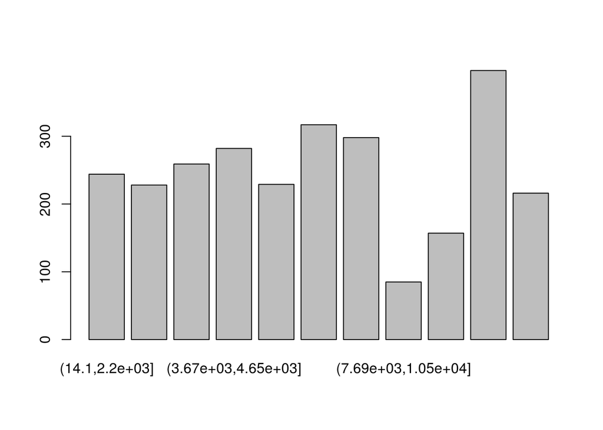

```r
plot(bin(data = ad$capitalgain[ad$capitalgain > 0], method = "content", nbins = 11))
```

Another approach is to use the `cluster` method. Given a number of bins it will try to find the best clustering by that number. One caveat is that it will generate an error if the cluster size is 0. One can try to get around this by providing initial cluster positions.

```r
table(bin(data = ad$capitalgain, method = "cluster", nbins = 3))
```

```
    (-100,5.82e+03] (5.82e+03,5.58e+04]    (5.58e+04,1e+05]
              31099                1303                 159
```

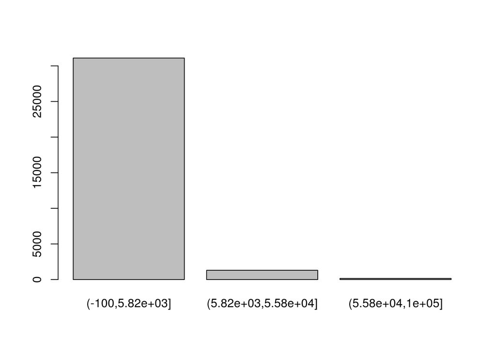

```r
plot(bin(data = ad$capitalgain, method = "cluster", nbins = 3))
```

One last option offered by `OneR` is to use targeted binning. This may be questionable because it might be biasing the results or adding hidden additional degrees of freedom (Harrell).

To do this, I create a temporary data frame with just the variables involved. Optbin then operates on that data frame and based on the method chosen, will bin the data optimally.

```r
tmp <- data.frame(capitalgain = ad$capitalgain)
tmp <- cbind(tmp, ad$income)

summary(optbin(tmp, method = "logreg"))
```

```
           capitalgain    ad$income
 (-100,4.01e+03] :30665   <=50K:24720
 (4.01e+03,1e+05]: 1896   >50K : 7841
```

```r
summary(optbin(tmp, method = "infogain"))
```

```
           capitalgain    ad$income
 (-100,7.07e+03] :31162   <=50K:24720
 (7.07e+03,1e+05]: 1399   >50K : 7841
```

The difference between these two methods is that `logreg` puts the split at around $4,010, and `infogain` puts it at $7,070.

Because this variable is so skewed with 0, I’ll just choose to use the `infogain` method to come up with a low/high value.

```r
tmp <- data.frame(capitalgain = ad$capitalgain)
tmp <- cbind(tmp, ad$income)

ad$capitalgain <- optbin(tmp, method = "infogain")$capitalgain
levels(ad$capitalgain) <- c("low", "high")

summary(ad$capitalgain)
```

```
  low  high
31162  1399
```

#### Capital-Loss

Let’s look at `capitalloss`.

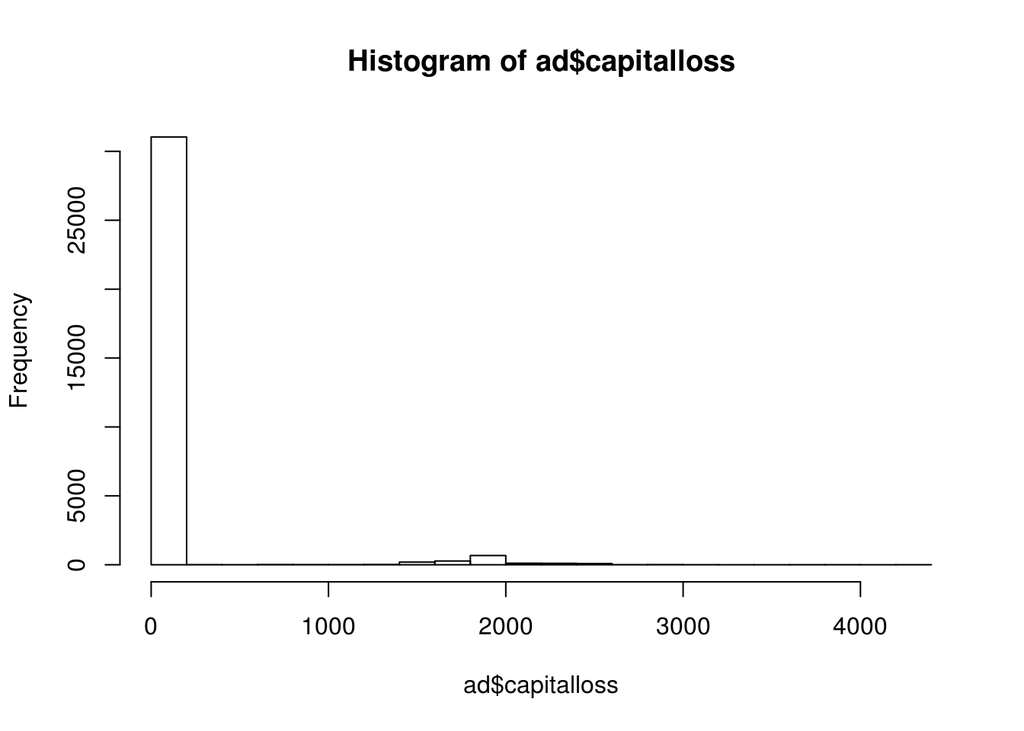

```r
hist(ad$capitalloss)
```

It looks a lot like `capitalgain`, so for expedience, we can apply the targeted `optbin` method.

```r
tmp <- data.frame(capitalloss = ad$capitalloss)
tmp <- cbind(tmp, ad$income)

ad$capitalloss <- optbin(tmp, method = "infogain")$capitalloss
levels(ad$capitalloss) <- c("low", "high")

summary(ad$capitalloss)
```

```
  low  high
31570   991
```

#### Hours-per-Week

With Hours-per-Week, there is probably a good basis for 3-bins like: “half-time”, “full-time”, “over-time”. But in this case, I’d like to bin with the DMIT-recommended 12 bins, using a content-based method.

```r
table(bin(data = ad$hoursperweek, method = "content", nbins = 12))
```

```
(0.902,20]    (20,32]    (32,40]    (40,45]    (45,50]    (50,56]
      2928       2588      17464       2442       3496       1008
 (56,99.1]
      2635
```

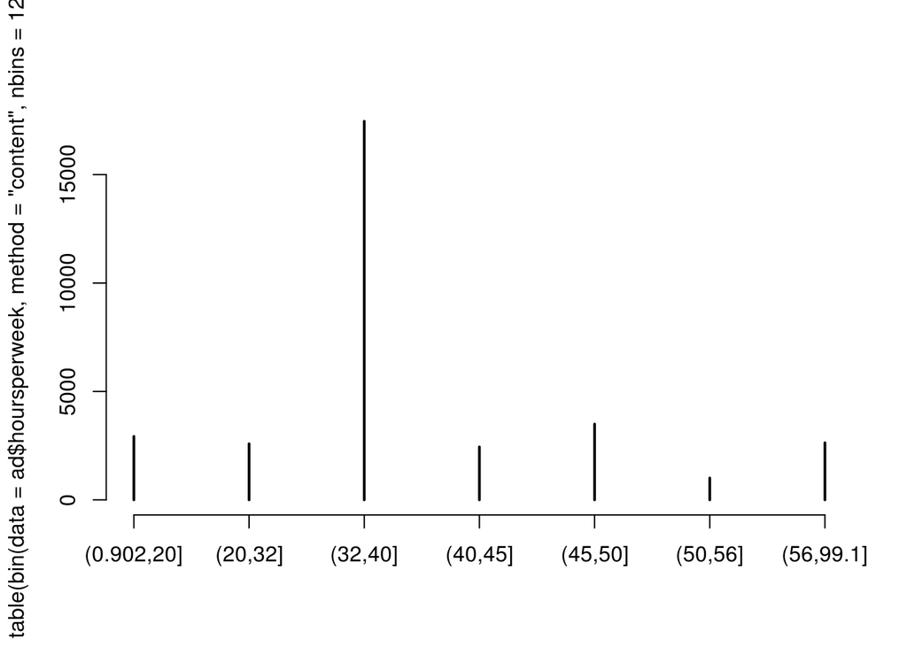

```r
plot(table(bin(data = ad$hoursperweek, method = "content", nbins = 12)))
```

In this case, the `quantile` method used only allowed for 7 bins, but the results look reasonable and we can always group some of the bins if necessary.

```r
ad$hoursperweek <- bin(data = ad$hoursperweek, method = "content", nbins = 12)
```

#### The Data Looks Ready!

We’ve now discretized all the variables in our data frame.

```r
str(ad)
```

```
'data.frame':   32561 obs. of  13 variables:
 $ age          : Factor w/ 12 levels "(15,25]","(25,30]",..: 4 6 4 7 2 4 6 7 3 5 ...
 $ workclass    : Factor w/ 9 levels "?","Federal-gov",..: 8 7 5 5 5 5 5 7 5 5 ...
 $ education    : Factor w/ 16 levels "Preschool","1st-4th",..: 13 13 9 7 13 14 5 9 14 13 ...
 $ maritalstatus: Factor w/ 7 levels "Divorced","Married-AF-spouse",..: 5 3 1 3 3 3 4 3 5 3 ...
 $ occupation   : Factor w/ 15 levels "?","Adm-clerical",..: 2 5 7 7 11 5 9 5 11 5 ...
 $ relationship : Factor w/ 6 levels "Husband","Not-in-family",..: 2 1 2 1 6 6 2 1 2 1 ...
 $ race         : Factor w/ 5 levels "Amer-Indian-Eskimo",..: 5 5 5 3 3 5 3 5 5 5 ...
 $ sex          : Factor w/ 2 levels "Female","Male": 2 2 2 2 1 1 1 2 1 2 ...
 $ capitalgain  : Factor w/ 2 levels "low","high": 1 1 1 1 1 1 1 1 2 1 ...
 $ capitalloss  : Factor w/ 2 levels "low","high": 1 1 1 1 1 1 1 1 1 1 ...
 $ hoursperweek : Factor w/ 7 levels "(0.902,20]","(20,32]",..: 3 1 3 3 3 3 1 4 5 3 ...
 $ nativecountry: Factor w/ 42 levels "?","Cambodia",..: 40 40 40 40 6 40 24 40 40 40 ...
 $ income       : Factor w/ 2 levels "<=50K",">50K": 1 1 1 1 1 1 1 2 2 2 ...
```

## Good Machine Learning Practice - Designating Test Data

In machine learning, it’s important to set aside some data for testing your models on. Your training and parameter tuning should never see this data. It becomes the final, and hopefully unbiased, yard-stick by which to measure your models.

There is plenty of debate about how much data should be set aside. In this case, I’ll randomly choose 20% of the data to be set aside as *test* data. I’ll set up a vector with a `TRUE` or `FALSE` for each row in the dataset. This will be used by our function for taking a data frame and making it into an OCCAM file.

(Side note: UCIML already offers separate training and test files for this data set. It might have been more appropriate to load both files and explicitly mark the test data as such.)

```r
set.seed(3141593)    # setting the random seed to ensure the same results every time we generate this document

test_prob <- 0.2
test_rows <- sample(x = c(TRUE, FALSE), size = nrow(ad), replace = TRUE, prob = c(test_prob, 1 - test_prob))

# now investigate:
head(test_rows)
```

```
[1] FALSE FALSE FALSE FALSE FALSE  TRUE
```

```r
summary(test_rows)
```

```
   Mode   FALSE    TRUE
logical   25964    6597
```

```r
# to check the percentage
paste("% Test Rows: ", 100 * as.numeric(summary(test_rows)[["TRUE"]]) / nrow(ad))
```

```
[1] "% Test Rows:  20.260434261847"
```

## Generating an OCCAM Data Set

I’ve created a function, `make_OCCAM_data` that will create an OCCAM compliant data file from our data frame.

```r
occam_data <- make_OCCAM_data(ad, DV=13, test_rows = test_rows)

# the first 30 rows of the OCCAM data
options(width = 10)
head(occam_data, n = 30)
```

```
 [1] "# OCCAM DATA FILE"
 [2] ""
 [3] ":nominal"
 [4] "age, 12, 1, a"
 [5] "workclass, 9, 1, b"
 [6] "education, 16, 1, c"
 [7] "maritalstatus, 7, 1, d"
 [8] "occupation, 15, 1, e"
 [9] "relationship, 6, 1, f"
[10] "race, 5, 1, g"
[11] "sex, 2, 1, h"
[12] "capitalgain, 2, 1, i"
[13] "capitalloss, 2, 1, j"
[14] "hoursperweek, 7, 1, k"
[15] "nativecountry, 42, 1, l"
[16] "income, 2, 2, z"
[17] ""
[18] ":no-frequency"
[19] ""
[20] ":data"
[21] "4 8 13 5 2 2 5 2 1 1 3 40 1"
[22] "6 7 13 3 5 1 5 2 1 1 1 40 1"
[23] "4 5 9 1 7 2 5 2 1 1 3 40 1"
[24] "7 5 7 3 7 1 3 2 1 1 3 40 1"
[25] "2 5 13 3 11 6 3 1 1 1 3 6 1"
[26] "3 5 14 5 11 2 5 1 2 1 5 40 2"
[27] "5 5 13 3 5 1 5 2 1 1 3 40 2"
[28] "4 5 10 3 5 1 3 2 1 1 7 40 2"
[29] "2 8 13 3 11 1 2 2 1 1 3 20 2"
[30] "1 5 13 5 2 4 5 1 1 1 2 40 1"
```

And now write the data to a file.

```r
filename <- "adult01.txt"
fileConn <- file(filename)
writeLines(occam_data, fileConn)
close(fileConn)
```

## Now to ANALYZE THE DATA!!!

Before we get going with OCCAM, it might be interesting to use `OneR` to find which single variable is the most predictive.

### OneR

Running `OneR` will let us know which variable is most predictive and how the values predict the dependent variable. With the `verbose` output, this should be the equivalent of done a 1-level, bottom-up search in OCCAM, with single-variable models. We’re using the same training/test split for `OneR` as we are for OCCAM.

```r
options(width = 80)
training <- ad[test_rows==FALSE, ]
test     <- ad[test_rows==TRUE, ]

model <- OneR(training, verbose = TRUE)
```

```
    Attribute     Accuracy
1 * capitalgain   80.02%
2   education     77.95%
3   capitalloss   77.19%
4   workclass     76.27%
5   age           75.87%
5   maritalstatus 75.87%
5   occupation    75.87%
5   relationship  75.87%
5   race          75.87%
5   sex           75.87%
5   hoursperweek  75.87%
5   nativecountry 75.87%
---
Chosen attribute due to accuracy
and ties method (if applicable): '*'
```

```r
summary(model)
```

```
Call:
OneR.data.frame(x = training, verbose = TRUE)

Rules:
If capitalgain = low  then income = <=50K
If capitalgain = high then income = >50K

Accuracy:
20777 of 25964 instances classified correctly (80.02%)

Contingency table:
       capitalgain
income      low   high   Sum
  <=50K * 19682     16 19698
  >50K     5171 * 1095  6266
  Sum     24853   1111 25964
---
Maximum in each column: '*'

Pearson's Chi-squared test:
X-squared = 3507.2, df = 1, p-value < 2.2e-16
```

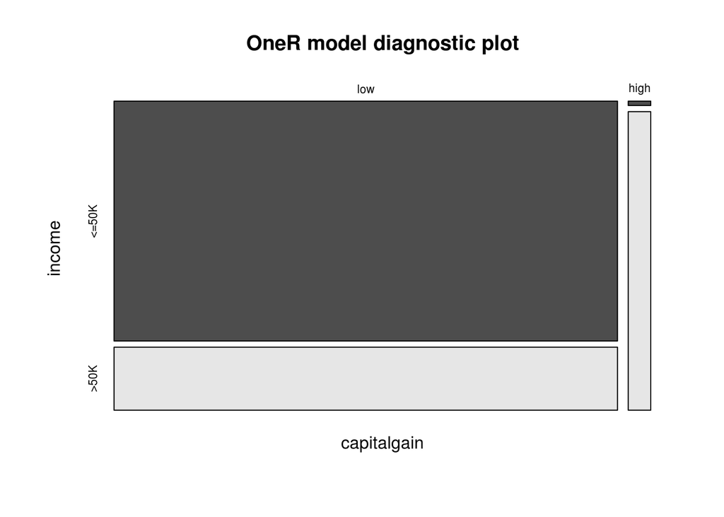

```r
plot(model)
```

```r
prediction <- predict(model, test)

eval_model(prediction, test)
```

```
Confusion matrix (absolute):
          Actual
Prediction <=50K >50K  Sum
     <=50K  5018 1291 6309
     >50K      4  284  288
     Sum    5022 1575 6597

Confusion matrix (relative):
          Actual
Prediction <=50K >50K  Sum
     <=50K  0.76 0.20 0.96
     >50K   0.00 0.04 0.04
     Sum    0.76 0.24 1.00

Accuracy:
0.8037 (5302/6597)

Error rate:
0.1963 (1295/6597)

Error rate reduction (vs. base rate):
0.1778 (p-value < 2.2e-16)
```

According to `OneR`, `capitalgain` is the best single variable for predicting `income`.

### OCCAM Variable-Based Model - Single Variable

To compare with `OneR`, I decided to start with running a single-variable/1-level search in OCCAM.

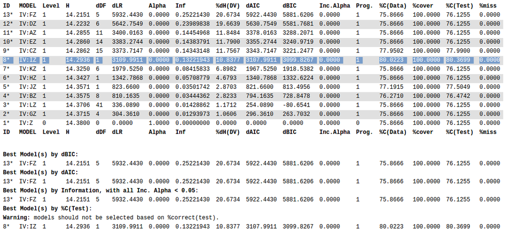

We can see that OCCAM and `OneR` agree that `I`, or `capitalgains` are the best predictor when looking at accuracy on the training data.

### OCCAM Variable-Based Model w/o Loops

Running OCCAM with the defaults (directed and loopless), the results are below.

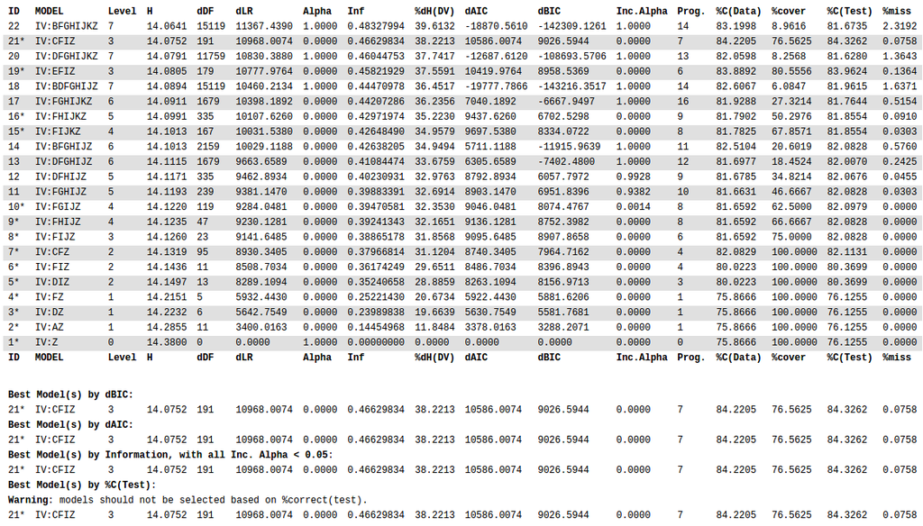

The best model, by all criteria, is `IV:CFIZ`, where C is education, F is relationship, and I is capitalgain.

Relationship looks like a strange variable, and it’s not clear what it represents. Comparing it to `sex` yields:

```r
table(ad[,c(6,8)])
```

```
                sex
relationship     Female  Male
  Husband             1 13192
  Not-in-family    3875  4430
  Other-relative    430   551
  Own-child        2245  2823
  Unmarried        2654   792
  Wife             1566     2
```

The best I can tell from reading the US Census site is that on a Census form, all the people in a house-hold are listed in a single report. Then relationship tells how the additional people are related to the primary person filling the form. I’m just puzzled about why that would be relevant.

I have to admit I was pleased to see `capitalgain` made the list!

### A model *with* loops

Now allowing for loops (which took about 3 minutes to run):

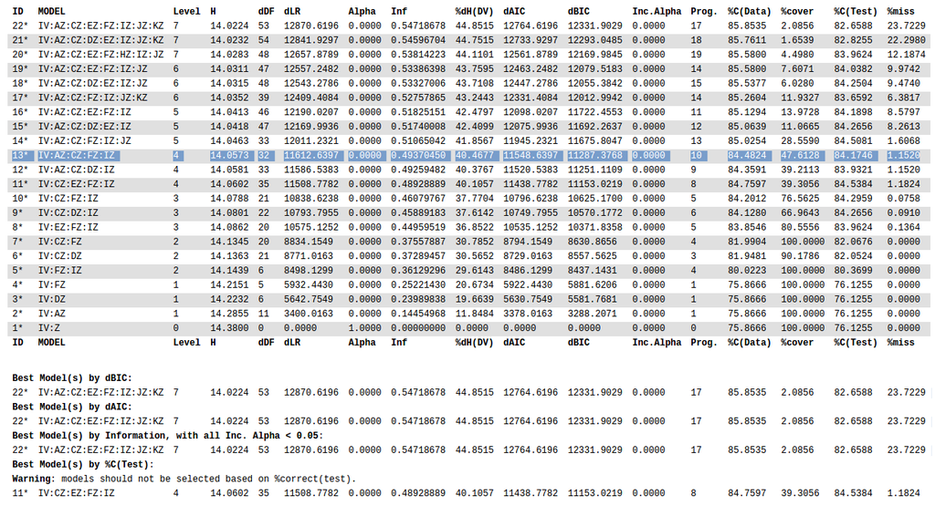

Here, the best model by dBIC is `IV:AZ:CZ:EZ:FZ:IZ:JZ:KZ`, giving us: age, education, occupation, relationship, capitalgain, capitalloss, and hoursperweek. However this is over half the variables available!

I lean towards choosing `IV:AZ:CZ:FZ:IZ`. It uses fewer variables (age, education, relationship, and capitalgain), losing only 8.4701129 % of dBIC, and only 1.3711 points of accuracy (against the data), while improving dDF by 21 degrees.

#### A State-Based Model Search

To do a state-based search, we’ll need to tell OCCAM to ignore some variables, otherwise it won’t run (the state-space is too large!). Here I set up the columns to ignore then see what we’re keeping. Starting with the model from above: `IV:AZ:CZ:FZ:IZ`, we’ll modify and generate a new OCCAM file by setting “ignore” on the unwanted variables.

```r
keep <- c(1, 3, 6, 9, 13)
ignore <- setdiff(1:13, keep)

str(ad[ , keep])
```

```
'data.frame':   32561 obs. of  5 variables:
 $ age         : Factor w/ 12 levels "(15,25]","(25,30]",..: 4 6 4 7 2 4 6 7 3 5 ...
 $ education   : Factor w/ 16 levels "Preschool","1st-4th",..: 13 13 9 7 13 14 5 9 14 13 ...
 $ relationship: Factor w/ 6 levels "Husband","Not-in-family",..: 2 1 2 1 6 6 2 1 2 1 ...
 $ capitalgain : Factor w/ 2 levels "low","high": 1 1 1 1 1 1 1 1 2 1 ...
 $ income      : Factor w/ 2 levels "<=50K",">50K": 1 1 1 1 1 1 1 2 2 2 ...
```

##### Adjusting Cardinality of Age

We should also consider reducing the cardinality of some of the larger variables such as `age` and `education`. We covered `age` earlier and can simply group the existing lower level hierarchy to the next level up.

```r
# Old: 15-24, 25-29, 30-34, 35-39, 40-44, 45-49, 50-54, 55-59, 60-64, 65-69, 70-74, 75+
# New: 15-24, 25-34,        35-44,        45-54,        55-64,        65-74,        75+

# make a new vector with the new factor labels.  In the data above the non-end factors are grouped by 2s
# so the new vector states the new factor twice for each of those
new_age_breaks <- c("15-24",
                    "25-34", "25-34",   # encompases 25-29 and 30-34
                    "35-44", "35-44",
                    "45-54", "45-54",
                    "55-64", "55-64",
                    "65-74", "65-74",
                    "75+")

# make a copy of the age variable because we don't want to make this change to our data (just yet)

levels(ad$age) <- new_age_breaks

str(ad$age)
```

```
 Factor w/ 7 levels "15-24","25-34",..: 3 4 3 4 2 3 4 4 2 3 ...
```

##### Adjusting Cardinality of Education

There is probably an obvious place to break `education`, since years of education and income are probably well-correlated. We can investigate how to group the levels using `OneR`.

```r
OneR(ad[,c(1, 3, 6, 13)], verbose = TRUE)
```

```
    Attribute    Accuracy
1 * education    77.96%
2   age          75.92%
2   relationship 75.92%
---
Chosen attribute due to accuracy
and ties method (if applicable): '*'
```

```
Call:
OneR.data.frame(x = ad[, c(1, 3, 6, 13)], verbose = TRUE)

Rules:
If education = Preschool    then income = <=50K
If education = 1st-4th      then income = <=50K
If education = 5th-6th      then income = <=50K
If education = 7th-8th      then income = <=50K
If education = 9th          then income = <=50K
If education = 10th         then income = <=50K
If education = 11th         then income = <=50K
If education = 12th         then income = <=50K
If education = HS-grad      then income = <=50K
If education = Some-college then income = <=50K
If education = Assoc-voc    then income = <=50K
If education = Assoc-acdm   then income = <=50K
If education = Bachelors    then income = <=50K
If education = Masters      then income = >50K
If education = Prof-school  then income = >50K
If education = Doctorate    then income = >50K

Accuracy:
25384 of 32561 instances classified correctly (77.96%)
```

```r
# "Preschool", "1st-4th", "5th-6th","7th-8th", "9th", "10th", "11th", "12th", "HS-grad", "Some-college", "Assoc-voc", "Assoc-acdm", "Bachelors", "Masters", "Prof-school", "Doctorate"
# New: 15-24, 25-34,        35-44,        45-54,        55-64,        65-74,        75+

# make a new vector with the new factor labels.  In the data above the non-end factors are grouped by 2s
# so the new vector states the new factor twice for each of those
new_ed_breaks <- c("K12", "K12", "K12", "K12", "K12", "K12", "K12", "K12", "<=HS",
                    "<=Bachelors", "<=Bachelors", "<=Bachelors", "<=Bachelors",
                    "Graduate", "Graduate", "Graduate")

# make a copy of the age variable because we don't want to make this change to our data (just yet)

levels(ad$education) <- new_ed_breaks

str(ad$education)
```

```
 Factor w/ 4 levels "K12","<=HS","<=Bachelors",..: 3 3 2 1 3 4 1 2 4 3 ...
```

And now modify our OCCAM file.

```r
occam_data <- make_OCCAM_data(ad, DV=13, test_rows = test_rows, ignore_cols = ignore)


filename <- "adult04.txt"
fileConn <- file(filename)
writeLines(occam_data, fileConn)
close(fileConn)
```

To get SB-Search to even run, it was necessary to reduce the cardinality as above. That yielded the below.

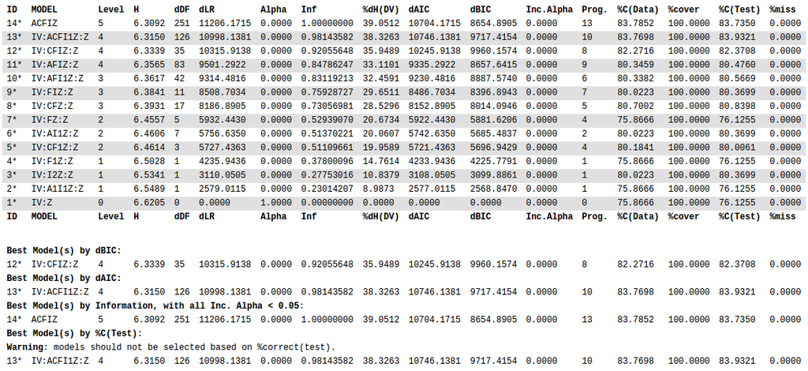

It appears that the cardinality reduction weakened the models so that the variable-based models with loops give the best result.

## Appendix: Useful Links while Writing This Vignette

Here are some sites that help solve various problems used in generating this document.

- Embedding another `.R` file in this document without copying it in directly: [Making use of external R code in knitr and R markdown](http://zevross.com/blog/2014/07/09/making-use-of-external-r-code-in-knitr-and-r-markdown/)
- Outputing the character vector one per line (non-interleaved) to make OCCAM file look correct in this document: [Print an R vector vertically](https://stackoverflow.com/questions/25223977/print-an-r-vector-vertically)
- Making R output not have beginning hashes: [Remove Hashes in R Output from RMarkdown and Knitr](https://stackoverflow.com/questions/15081212/remove-hashes-in-r-output-from-rmarkdown-and-knitr)
- Getting unique pairs of values from two variables: [unique() for more than one variable](https://stackoverflow.com/questions/7790732/unique-for-more-than-one-variable)
- Changing single column names in a data frame: [Changing column names of a data frame](https://stackoverflow.com/questions/6081439/changing-column-names-of-a-data-frame)
- Changing the ordering of factors: [Changing the order of levels of a factor](http://www.cookbook-r.com/Manipulating_data/Changing_the_order_of_levels_of_a_factor/)
- Dropping a data frame column by name: [Drop data frame columns by name](https://stackoverflow.com/questions/4605206/drop-data-frame-columns-by-name)
- Removing white-space while importing csv: [R fread and strip white](https://stackoverflow.com/questions/22757353/r-fread-and-strip-white)
- Extracting values from output functions like `summary`: [How do I extract just the number from a named number (without the name)?](https://stackoverflow.com/questions/15736719/how-do-i-extract-just-the-number-from-a-named-number-without-the-name)
- Grouping factors - as in the hierarchies of age: [Grouping 2 levels of a factor in R](https://stackoverflow.com/questions/9604001/grouping-2-levels-of-a-factor-in-r)
- Using `optbin` from `OneR`: optbin

## References

Kohavi R., Becker B., “Adult”, http://archive.ics.uci.edu/ml/datasets/Adult, UCI Machine Learning Repository http://archive.ics.uci.edu/ml. (1996), Irvine, CA: University of California, School of Information and Computer Science. (2017)

Harrell, Frank, “Problems Caused by Categorizing Continuous Variables”, http://biostat.mc.vanderbilt.edu/wiki/Main/CatContinuous, (2017)